# The Basal Ganglia

2025

## Key brain regions of basal ganglia (BG) circuits

- Cerebral cortex (ctx)
- Striatum expressing D1-type dopamine receptors (str_d1)
- Striatum expressing D2-type dopamine receptors (str_d2)
- Internal segment of the globus pallidus (gpi)
- External segment of the globus pallidus (gpe)
- Thalamus (thl)
- Subthalamic nucleus (stn)

## Closed loop circuits of the BG

- The direct pathway (Go)
  - ctx \(\rightarrow\) str_d1 \(\dashv\) gpi \(\dashv\) thl \(\rightarrow\) ctx
- The indirect pathway (NoGo)
  - Version 1: ctx \(\rightarrow\) str_d2 \(\dashv\) gpe \(\dashv\) stn \(\rightarrow\) gpi \(\rightarrow\) thl \(\rightarrow\) ctx
  - Version 2: ctx \(\rightarrow\) str_d2 \(\dashv\) gpe \(\dashv\) gpi \(\dashv\) thl \(\rightarrow\) ctx
- The hyperdirect pathway (Stop / gain regulation)
  - ctx \(\rightarrow\) stn \(\rightarrow\) gpi \(\dashv\) thl \(\rightarrow\) ctx

## Electrophysiological properties of key neurons in the basal ganglia

- Striatal cells (D1-type and D2-type cells) have interesting elecrophysiological properties, so they are deserving of a special set of izhikevich model parameters.
- Every other cell in the network can be modeled with a regular spiking neuron.

## Striatal Projection Neurons (SPNs)

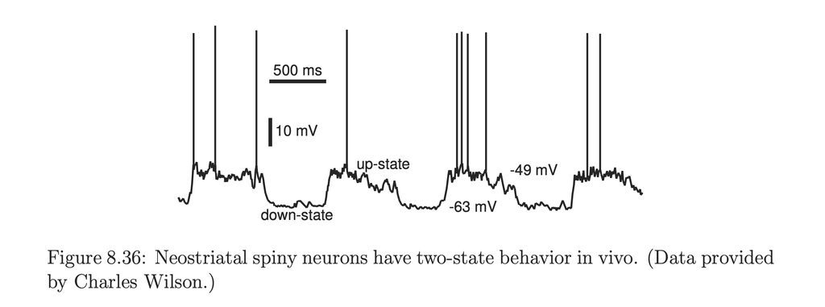

## Striatal Projection Neurons (SPNs)

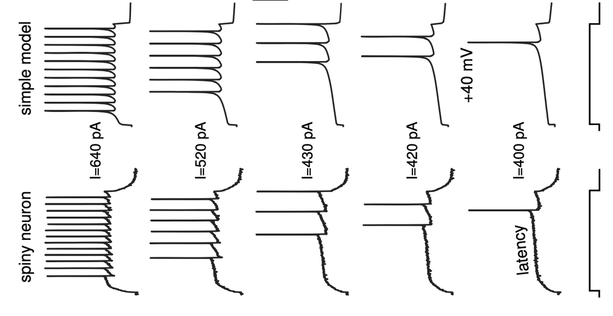

## Striatal Projection Neurons (SPNs)

```python
# # striatal projection neuron
# C = 50; vr = -80; vt = -25; vpeak = 40;
# a = 0.01; b = -20; c = -55; d = 150; k = 1;

# # regular spiking neuron
# C = 100; vr = -60; vt = -40; vpeak = 35;
# a = 0.03; b = -2; c = -50; d = 100; k = 0.7;
```

## Striatal Projection Neurons (SPNs)

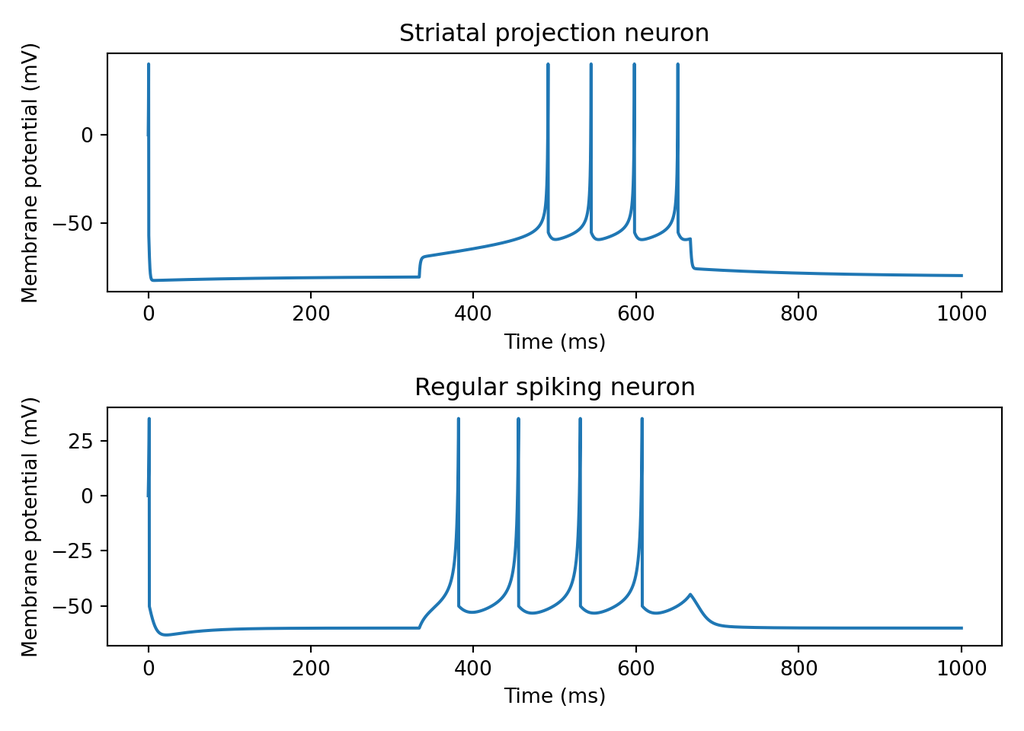

## GPi and GPe neurons

- Both segments of the globus pallidus have high baseline firing rates (they fire a high frequency train of action potentials even in the absence of excitatory inputs).
- We will model baseline firing with an additional parameter \(E\) acting just like a tonic external current.

\[ \begin{align*} \frac{dv}{dt} &= \left[ k(v - v_r)(v - v_t) - u + I + E \right] \frac{1}{C} \\ \frac{du}{dt} &= a(b(v - v_r) - u) \\ \end{align*} \]

## GPi and GPe neurons

```python
for i in range(1, n):
    dvdt = (k*(v_rsn[i-1] - vr)*(v_rsn[i-1] - vt) - u_rsn[i-1] + E + I[i-1]) / C
    dudt = a*(b*(v_rsn[i-1] - vr) - u_rsn[i-1])

    v_rsn[i] = v_rsn[i-1] + dvdt*dt
    u_rsn[i] = u_rsn[i-1] + dudt*dt

    if v_rsn[i] >= vpeak:
        v_rsn[i-1] = vpeak
        v_rsn[i] = c
        u_rsn[i] += d
```

## GPi and GPe neurons

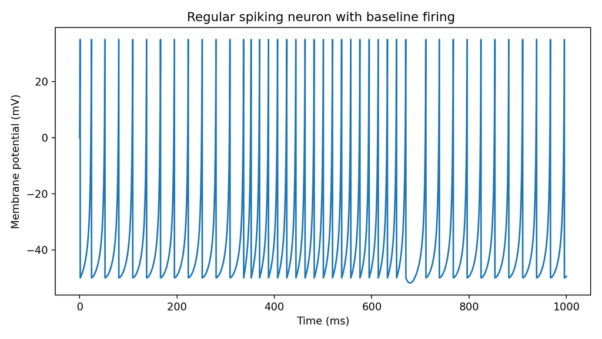

## The BG network

```python
# C, vr, vt, vpeak, a, b, c, d, k, E
iz_params = np.array([
    [100, -60, -40, 35, 0.03, -2, -50, 100, 0.7, 0],   # ctx
    [50, -80, -25, 40, 0.01, -20, -55, 150, 1, 0]      # str_d1
    [50, -80, -25, 40, 0.01, -20, -55, 150, 1, 0]      # str_d2
    [100, -60, -40, 35, 0.03, -2, -50, 100, 0.7, 100], # gpi
    [100, -60, -40, 35, 0.03, -2, -50, 100, 0.7, 100], # gpe
    [100, -60, -40, 35, 0.03, -2, -50, 100, 0.7, 0],   # stn
    [100, -60, -40, 35, 0.03, -2, -50, 100, 0.7, 0],   # thl
])
```

## The BG network

```python
n_cells = iz_params.shape[0]
w = np.zeros((n_cells, n_cells))

# Direct pathway: ctx -> str_d1 -> gpi -> thl -> ctx
w[0, 1] = 1 # ctx -> str_d1
w[1, 3] = 1 # str_d1 -> gpi
w[3, 6] = 1 # gpi -> thl
w[6, 0] = 1 # thl -> ctx

# Indirect pathway: ctx -> str_d2 -> gpe -> gpi -> thl -> ctx
w[0, 2] = 1 # ctx -> str_d2
w[2, 4] = 1 # str_d2 -> gpe
w[4, 3] = 1 # gpe -> gpi
w[3, 6] = 1 # gpi -> thl

# Hyperdirect pathway: ctx -> stn -> gpi -> thl -> ctx
w[0, 5] = 1 # ctx -> stn
w[5, 3] = 1 # stn -> gpi
w[3, 6] = 1 # gpi -> thl
```

## The BG network

```python
for i in range(1, n): # iterate over time steps
    for post in range(3): # iterate over post-synaptic neurons

        pre_synaptic = w[:, post] @ g[:, i-1] # matrix multiplication

        # C, vr, vt, vpeak, a, b, c, d, k, E
        C = iz_params[post, 0]
        vr = iz_params[post, 1]
        vt = iz_params[post, 2]
        vpeak = iz_params[post, 3]
        a = iz_params[post, 4]
        b = iz_params[post, 5]
        c = iz_params[post, 6]
        d = iz_params[post, 7]
        k = iz_params[post, 8]
        E = iz_params[post, 9]

        # update post-synaptic neuron...
        # Update the state variables...
        # Update spike records...
```